# Question 1 (2 points)

1. (0.5 points) Explain what L1 and L2 regularization do, in general terms.
2. (0.5 points) Explain the difference between L1 and L2 regularization and say what advantage(s) each one confers. Put another way: explain when you might use one over the other.
3. (1 point) Give some reasons why you think Dropout can mitigate the overfitting issue (useful readings: https://www.cs.toronto.edu/~hinton/absps/JMLRdropout.pdf)?

**ANSWER Q1**

1. L1 encoruages parameters to be sparse (0) by penalizing high values of the l1 norm of the model parameters. L2 encourages parameters to be small but never actually 0 by penalizing high values of the l2-norm. These both use a lambda value that dictates by how much you regularize the data. For example, with L2 regularization, with a higher value for lambda, it will most intensly shift values closer to 0. They are both used as regularization techniques to reduce test error at the expense of an increase of training error.
2. The textbook notes that the "sparsity property induced by L1 regularization has been used...as a feature selection mechanism" (Chp 7. 232). This means that certain weights are set to zero, so certain features can safely be ignored because they are less important for the task. L2 regularization is used when you don't want to ignore the effects of specific weights, but create a more stable/generalizable model that still uses the weights, they just have less of an affect rather than none.
3. The reason that Dropout can mitigate against overfitting issues, is that it trains an "ensemble" of subnetworks. It essentially thins networks and then averages these predictions into a single generalization that helps reduce overfitting. If we think back to the lecture slides, we can get difference loss landscapes from different examples. By removing certain units from a network, we effectively adjust the loss landscape, in turn making our model more generalizable over the entire dataset, rather than overfitting on one landscape, but getting closer to the true landscape.

# Question 2 (3 points)

You're an ML engineer working with the artist [Invader](https://www.space-invaders.com/world/), who is famous for their mosaic artworks placed in public spaces in large cities around the world. The artist also has a mobile game called Flash Invaders that lets people collect the invader mosaics by visiting the artworks around the world and taking pictures of them, trying to collect as many as they can. Your task as an ML engineer is to develop an image classifier that uses a neural network to detect whether an input image contains an invader artwork or not.

[figure not shown]

Screenshots of the Flash Invaders game. The game lets users take photos of the artworks from their phone and rewards them with +30 points if the photo contains an invader artwork in it. Your job is to implement an ML algorithm for classifying whether a photo taken by a user contains an invader artwork in it or not, like in the figure above.

The artist has given you an image dataset of the artworks that your algorithm is supposed to identify, as shown above. Your initial dataset contains photos of **all** of the artworks you need to identify. However, **all of these photos were taken in the artist's studio**, before the art was installed in the public venues, which means they were all taken at a **perfect angle and lightning** and have no background

[figure not shown]

This is an excerpt of the dataset you will have available for training. Notice that all of the artworks are digital illustrations and not real photos, meaning that they are under perfect lighting conditions and camera angles.

[figure not shown]

These are the kind of photos your machine learning will receive as input.

In the real world, your model will receive as input photos taken by users from their phones, which means that the photos will be taken under different conditions than the ones in your training dataset. For example, look at the photos above.

Your task is to figure out a data augmentation scheme that will improve the performance of your machine learning model under unseen conditions.

1. **(1 point)** How is your training data different from the data your model will be presented at inference time? What are the different real-world conditions that you think could affect your model's ability to accurately identify the artworks?
2. **(1 point)** Explain any data augmentation techniques you could use to make your model robust to the real-world conditions you described above.
3. **(1 point)** Explain a data augmentation technique that does not make sense in terms of our desired task, and would not improve our model's performance.

**ANSWER Q2**

1. Our training data are the pictures taken with the same lighting at the perfect angle in a studio. However, at inference time, our model will receive images from various angles, lighting, phone cameras, etc... The time of day and the angle of the sun can cause shadows, the angle the photo was taken, the distance away that the photo was taken, the weather conditions, are some of the many real-world conditions that could affect our model's ability to acurrately identify the artworks.
2. Similar to what we discussed in class, it could be useful to use torchvisions' transforms to sequentially adjust the data in these ways I described above. I would be able to crop, move around, change lighting, adjust orientation, and lots more with these transforms to better model what the data may look like at inference.
3. We have to be careful about which transformations to make. It is difficult to say which would negatively impact our model performance, however, by doing too many transformtions to the orientation of a single class (like flipping it or rotating it too much as mentioned in the textbook with the "b" and "d" example) can negatively impact how our model identifies a certain object! So I have to be careful by how much I am adjusting the transformations.

# Question 3 (3 points)

In this question, you will do your best to make a network to embody the function $y=x_1 * x_2$. Here, assume $x_1,x_2 \in {\Bbb R}$ and $x_1,x_2 \in (-1000,1000)$.

Assume you are starting from random weight initialization. Feel free to use any of the Non-linear Activations (weighted sum, nonlinearity) in [torch.nn](https://pytorch.org/docs/stable/nn.html#non-linear-activations-weighted-sum-nonlinearity). Use as many layers as you like. Make the layers as big as you like.

- Note, you are not allowed to simply put some variant of $output = x_1*x_2$ in your forward function.

You will make a training dataset and a test dataset using the provided dataset generator. Train the network on the training set and, once trained, test it on the test data. Make sure your test set is at minimum 1000 examples. Use mean-squared-error as your objective function. Then answer the following questions.

1. What was the best mean-squared-error you got on the training data?
2. What was the best mean-squared-error you got on the test data?
3. What challenges or difficulties did you encounter in implementing and training this network?

**ANSWER Q3**

As a baseline to test my model, I set the max_abs to 5 such that $x_1, x_2 \in (-5, 5)$. My train and test loss respectively got as low as: 0.0103 and 0.009

Now I did the same thing for $x_1, x_2 \in (-1000, 1000)$. And I got the following answers:

1. Best mean-squared-error from training: 207,937,280
2. Best mean-squared-error from testing: 79,595,280
3. I encountered lots of difficulty in lowering the loss in my model. My theory behind this is that to be able to predict the output accurately based on the input, you would have to have seen very similar examples multiple times, and MSE is largely impacted by the values passed in. By using large numbers between (-1000, 1000), it makes the parameter space huge for the model to learn AND MSE will be heavily skewed by such large numbers multiplied by eachother.

```python
# HERE'S A DATASET GENERATOR TO HELP YOU TEST/TRAIN.

import torch
import numpy as np
import torch.nn as nn
import torch.nn.functional as F
import torch.optim as optim
from torch.utils.data import DataLoader, Dataset

class MultiplyDataset(torch.utils.data.Dataset):
    """MULTIPLY Dataset."""

    def __init__(self, num_examples, max_abs=1000):
        """create a dataset of the form x_1 * x_2 = y. The input x_1, x_2 is a
        pair of values drawn from the default range [-1000, 1000]. The output y is a scalar.

        PARAMETERS
        ----------
        num_examples    An integer determining how much data we'll generate
        max_abs         The largest absolute value a datapoint can have
        """
        self.length = num_examples

        # make a circular unit Gaussian and draw samples from it
        data = np.random.uniform(low=-1, high=1, size=(self.length, 2))

        data *= max_abs
        # figure out the label (i.e. the result of the multiplication)
        label = np.multiply(data.T[0],data.T[1])

        # turn it into a tensor
        self.data =  torch.tensor(data).to(dtype=torch.float32)
        self.label = torch.tensor(label).to(dtype=torch.float32)

    def __len__(self):
        return self.length

    def __getitem__(self, idx):
        return self.data[idx], self.label[idx]
```

```python
class Net(nn.Module):
  def __init__(self):
    super().__init__()
    self.fc1 = nn.Linear(2, 1000)
    self.fc2 = nn.Linear(1000, 2048)
    self.fc3 = nn.Linear(2048, 1000)
    self.fc4 = nn.Linear(1000, 1)
    self.ac = nn.ReLU()

  def forward(self, x):
    x = self.ac(self.fc1(x))
    x = self.ac(self.fc2(x))
    x = self.ac(self.fc3(x))
    x = self.fc4(x)
    return x
```

```python
m_train = MultiplyDataset(5000)
m_test = MultiplyDataset(1000)


train_dl = DataLoader(m_train, batch_size=32, shuffle=True)
test_dl = DataLoader(m_test, batch_size=32, shuffle=True)
train_num_batches = len(train_dl)
test_num_batches = len(test_dl)

net = Net()
opt = optim.Adam(net.parameters(), lr=0.01)
loss_func = nn.MSELoss()
epochs = 100

print("Params: ", sum(p.numel() for p in net.parameters()))

training_loss = torch.zeros((epochs, ))
testing_loss = torch.zeros((epochs, ))

for i in range(epochs):

  # Training loop
  epoch_loss = 0.0

  for x, y in train_dl:
    net.train()
    opt.zero_grad()

    output = net(x)
    loss = loss_func(output.squeeze(), y)
    epoch_loss += loss.item()

    loss.backward()
    opt.step()

  epoch_loss /= train_num_batches
  training_loss[i] = epoch_loss

  print("Epoch: ", i, " loss: ", epoch_loss)


  # Testing loop
  epoch_loss = 0.0

  with torch.no_grad():
    for x, y in test_dl:
      pred = net(x)
      loss = loss_func(pred.squeeze(), y)
      epoch_loss += loss.item()
    epoch_loss /= test_num_batches
    testing_loss[i] = epoch_loss

best_training_loss = training_loss.min().item()
best_testing_loss = testing_loss.min().item()
print("best train loss = ", best_training_loss)
print("best test loss = ", best_testing_loss)
```

```
Params:  4103049
Epoch:  0  loss:  10698844667.10828
Epoch:  1  loss:  6089201724.33121
Epoch:  2  loss:  5875950013.961783
Epoch:  3  loss:  6652913285.707006
Epoch:  4  loss:  5477372539.923567
Epoch:  5  loss:  5063760023.643312
Epoch:  6  loss:  5352370321.121019
Epoch:  7  loss:  5453036239.082803
Epoch:  8  loss:  5196265776.917197
Epoch:  9  loss:  4945926401.630573
Epoch:  10  loss:  5229631329.834394
Epoch:  11  loss:  4932359516.942676
Epoch:  12  loss:  5019107551.3885355
Epoch:  13  loss:  4753709944.66242
Epoch:  14  loss:  4939595215.898089
Epoch:  15  loss:  4949854956.433121
Epoch:  16  loss:  5041540683.00637
Epoch:  17  loss:  4579193458.955414
Epoch:  18  loss:  4703647196.942676
Epoch:  19  loss:  4410103488.407643
Epoch:  20  loss:  4236395281.9363055
Epoch:  21  loss:  3928517671.133758
Epoch:  22  loss:  3723966796.2292995
Epoch:  23  loss:  3458621140.7898088
Epoch:  24  loss:  3447642606.0636945
Epoch:  25  loss:  3096048035.8726115
Epoch:  26  loss:  2841685623.8471336
Epoch:  27  loss:  2119733267.9745224
Epoch:  28  loss:  2577507536.917197
Epoch:  29  loss:  1773034396.942675
Epoch:  30  loss:  1421211598.8789809
Epoch:  31  loss:  1422287437.656051
Epoch:  32  loss:  2168602792.356688
Epoch:  33  loss:  974233406.77707
Epoch:  34  loss:  1350061626.089172
Epoch:  35  loss:  1018764635.6178344
Epoch:  36  loss:  689243188.0254776
Epoch:  37  loss:  1060239617.9363058
Epoch:  38  loss:  864252680.5605096
```

[output cut: 48 more lines]

```
Epoch:  87  loss:  289217863.6815287
Epoch:  88  loss:  644214094.8789809
Epoch:  89  loss:  618505042.1273885
Epoch:  90  loss:  382829111.84713376
Epoch:  91  loss:  230404436.81528664
Epoch:  92  loss:  303211883.15923566
Epoch:  93  loss:  518427914.42038214
Epoch:  94  loss:  324250431.49044585
Epoch:  95  loss:  452960903.27388537
Epoch:  96  loss:  393914309.22292995
Epoch:  97  loss:  582849219.2356688
Epoch:  98  loss:  399502722.9044586
Epoch:  99  loss:  661465978.1401274
best train loss =  207937280.0
best test loss =  79595280.0
```

# Question 4 (2 points)

We're now going to think about how easy or hard it is to solve the general multiplication problem for real numbers: $y= x_1*x_2$, when $x_1,x_2 \in {\Bbb R}$ are not bounded to the limited range (-1000,1000).

Define a "simple" feed-forward neural network as one where each layer $l$ takes input from only the previous layer $l-1$. Let's assume our simple feed-forward network only uses "standard" nodes. We'll define a "standard" one as one that take a weighted sum $z=\mathbf{w}^T\mathbf{x}$ of inputs $\mathbf{x}$, given weights $\mathbf{w}$, and then applies a differentiable activation function $f()$ to $z$. Example "standard" nodes include ReLu, Leaky ReLU, Sigmoid, TanH, and the linear/identity function.

Define "correctly" performing multiplication as estimating $\hat{y}= x_1*x_2$ to 2 decimal places of precision (i.e. $ |\hat{y}-y| < 0.01)$. Here, $\hat{y}$ is the network's result and $y$ is the true answer.

Is it possible to make a "simple" feed-forward neural network that can correctly perform multiplication for any arbitrary pair $x_1,x_2 \in {\Bbb R}$? **Support your answer.** This doesn't have to be a mathematical proof, but you do have to clearly explain your reasoning.

*Hint: Think about what a "standard" node calculates. Think about how you would implement multiplication using addition.*

**ANSWER Q4**

Somewhat following what I argued in Q3, I would argue that it is NOT possible to make a "simple" feed-forward neural network that can correctly perform multiplication for an arbitrary pair in the reals. What I mean by this is that a standard linear transformation computes the weighted sum such that $z = w^Tx$ of inputs $x$ gives weights $w$. This comes out to be $w_1 * x_1 + w_2 + x_2 \dots w_n * x_n$. This makes it noticeable that it is only modifying the sum of weighted values and inputs, and in turn cannot learn x1 * x2 between inputs. Alone, we know that multiplication cannot be learned by a linear function because multiplication is a non-linear function. Therefore, we attempt to use "standard" nodes like "ReLU, Leaky ReLU, Sigmoid, and TanH". Even with these standard activation functions to add non-linearity to the model, I would still argue that with large values for x1 and x2, a large nonconvex space is created where our model parameters would have to memorize all of the possible combinations (basically) in order to accurately learn these. We also must notice that with larger numbers multiplied together, it could cause exploding or vanishing gradients within our network. It is very possible that such large values for the output, combined with a loss function such as MSE, would create an extremely large loss value that is largely skewing the gradients. As I read through chapter 8 of the textbook, it is clear that a large number of factors could be causing this error, it is hard to say which is the main cause, but it could largely be the weight initializations, large number of minima that have a "high cost in comparison to the global minimum" in the non-convex neural space we have created, or even our lack of using gradient clipping to mitigate against the vanishing and exploding gradient problem.

This is why when the decision space was between (-5 and 5), our model was able to achieve low scores for loss to solve the multiplication problem, but as we increase the number of our absolute value range, it would be increasingly impossible to model due to its large decision space, lack of complexity of the model, and infinite space of the real numbers.

# Question 5 (2 points)

Suppose you want to build a fully convolutional network, YouNet, which converts an image with cropped ImageNet dimensions (256, 256), to MNIST dimensions (28, 28), and back to (256, 256). This network contains a convolutional layer that maps an image from (256, 256) -> (28, 28), and a transposed convolutional layer that maps an image from (28, 28) -> (256, 256).

```python
import torch
import torch.nn as nn

class YouNet(nn.Module):
    def __init__(self,
                 kernel_1: tuple[int, int],
                 kernel_2: tuple[int, int],
                 stride_1: tuple[int, int] = (1, 1),
                 stride_2: tuple[int, int] = (1, 1)):
        super().__init__()
        self.conv1 = nn.Conv2d(1, 1, kernel_1, stride=stride_1)
        self.conv2 = nn.ConvTranspose2d(1, 1, kernel_2, stride=stride_2)

    def forward(self, x: torch.Tensor) -> tuple[torch.Tensor, torch.Tensor]:
        mnist = self.conv1(x)
        imagenet = self.conv2(mnist)
        return mnist, imagenet
```

1. Find valid kernel sizes for the convolutional layers when `stride=(1, 1)`. You are not allowed to change YouNet definition of the convolutional layers. By 'valid', we mean that using the kernel results in a `mnist.shape` and an `imagenet.shape` that pass the assert statement below.

**ANSWER Q5a**

```python
kernel_1 = [229,229]
kernel_2 = [229,229]

network = YouNet(kernel_1, kernel_2)
mnist, imagenet = network(torch.zeros(1, 1, 256, 256))

print(imagenet.shape)
assert mnist.shape == (1, 1, 28, 28)
assert imagenet.shape == (1, 1, 256, 256)
```

```
torch.Size([1, 1, 256, 256])
```

2. Find valid (i.e. ones that pass the assert statement below) kernel sizes for when `stride=(8, 8)`

**ANSWER Q5b**

```python
kernel_1 = [33,33] # YOUR ANSWER GOES HERE
kernel_2 = [40,40]# YOUR ANSWER GOES HERE

network = YouNet(kernel_1, kernel_2, stride_1=(8, 8), stride_2=(8, 8))
mnist, imagenet = network(torch.zeros(1, 1, 256, 256))

print('mnist = ', mnist.shape)
print('imagenet = ',imagenet.shape)

assert mnist.shape == (1, 1, 28, 28)
assert imagenet.shape == (1, 1, 256, 256)
```

```
mnist =  torch.Size([1, 1, 28, 28])
imagenet =  torch.Size([1, 1, 256, 256])
```

3. Suppose instead of processing an image of size (256, 256) with the YouNet you implemented in part 2, you want to process an input image of size (257, 257). What would the sizes of the two processed output images be? Why doesn't the imagenet output have dimensionality (257, 257)? (Hint: Does the strided convolution process all the rows and columns of the original image?)

**ANSWER Q5c**

mnist = torch.Size([1, 1, 29, 29])

imagenet = torch.Size([1, 1, 264, 264])

The imagenet does not have the output dimensionality of 257x257 because it is an odd that is not divided evenly by 8. Because of this, the algorithm floors this value rather than leaving it as a floating point number. Because of this, I suppose you are losing the true information represented so when the deconvolution happens it will have a different number.

4. Suppose you are processing an image of size (264, 264) with the YouNet implemented in part 2. What would be the sizes of the two processed images output by the network? For an image of this size, does the imagenet output have the same size as the input?

**ANSWER Q5d**

mnist = torch.Size([1, 1, 29, 29])

imagenet = torch.Size([1, 1, 264, 264])

Yes the output has the same size as the input, but the expected value we were trying to get for the mnist dataset is wrong by 1 unit.

# Question 6 (3 points)

The paper [Batch Normalization: Accelerating Deep Network Training by Reducing Internal Covariate Shift](https://arxiv.org/pdf/1502.03167v3.pdf) is in our class readings list and describes one of the most popular normalization approaches.

Specifically, you are to reproduce the experiment in **section 4.1** of the paper, providing an output figure like **figure 1(a)**.

This means making a network module that has **the architecture described in section 4.1** of the paper. You will need to create two alternative versions of your network module: one model that has at least one batch normalization layer, another module that has no batch normalization layer. Pytorch provides a handy [function](https://pytorch.org/docs/stable/generated/torch.nn.BatchNorm1d.html) or [two](https://pytorch.org/docs/stable/generated/torch.nn.BatchNorm2d.html) to help with this.

- Note, you don't have to duplicate their weight initializations. Using the default weight initializations is fine.

The famous [MNIST](http://yann.lecun.com/exdb/mnist/) dataset is available in [torchvision.datasets](https://pytorch.org/vision/stable/datasets.html). You can download it just by declarng the dataset and specifying download=true. See the torchvision.dataset docs for more on that.

- Note, torchvision.datasets has both test and train datasets available for MNIST.
- Note, they never specify in the paper HOW BIG the testing (I think they mean VALIDATION, actually) set they use is. Yours could be just a couple of hundred examples.
- Note that you don't have to run the test after every training step. Every 20 training steps would be fine.
1. Put your graph similar to **figure 1(a)** from the paper below. The vertical dimension of your graph should be accuracy. The horizontal dimension should be number of training steps (not epochs). One training step = one update of model weights. NOTE: If you have a smaller validation set, your graph may be more noisy than the one in the paper. That's OK.

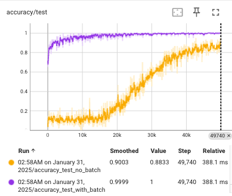

2. Put your analysis of the effectiveness of batch normalization for your network and dataset below. Did you duplicate their results?

**ANSWER Q6b**

I tried my best to model exactly what they did, and would say that I was relatively successful. The only true difference in their model from mine, was that the model without batch normalization had higher accuracy earlier on than mine did, but our batch normalized models look very similar. By reducing the internal covariate shift that the paper talks about, the model is able to learn quicker and stablize better.

3. Put all your code (including network modules, data loaders, testing and training code) below.

### Imports and Data

```python
import torch
import numpy as np
import torch.nn as nn
import torch.nn.functional as F
import torch.optim as optim
from torch.utils.data import DataLoader, Dataset
import torchvision
import torchvision.datasets as datasets
import matplotlib.pyplot as plt
import datetime
from pathlib import Path
from torch.utils.tensorboard import SummaryWriter
from google.colab import drive
import os

data_dir = "./data/"

if torch.cuda.is_available():
    device = torch.device("cuda:0")
    print("Using device:", torch.cuda.get_device_name(0))
else:
    device = torch.device("cpu")
    print("Using CPU")


# CONSTANTS
HIDDEN = 100
OUTPUT = 10
STEPS = 50000
BATCH_SIZE = 60
ACT = nn.Sigmoid()
LOSS_FUNC = nn.CrossEntropyLoss()

transform = torchvision.transforms.Compose([
    torchvision.transforms.ToTensor(),
    lambda x: x>0,
    lambda x: x.float(),
])

# Getting data
mnist_train_full = datasets.MNIST(data_dir, train=True, download=True, transform=transform)
mnist_train, mnist_val = torch.utils.data.random_split(mnist_train_full, [55000, 5000])

# Dataloaders
train_dataloader = torch.utils.data.DataLoader(mnist_train, batch_size=BATCH_SIZE, shuffle=True, pin_memory=True, num_workers=2)
val_dataloader = torch.utils.data.DataLoader(mnist_val, batch_size=BATCH_SIZE, shuffle=True, pin_memory=True, num_workers=2)
```

[output not shown]

[output not shown]

[output not shown]

[output not shown]

```
Extracting ./data/MNIST/raw/t10k-labels-idx1-ubyte.gz to ./data/MNIST/raw
```

### Model definitions

```python
class NoBatchModel(nn.Module):
  def __init__(self):
    super().__init__()
    self.fc1 = nn.Linear(28*28, HIDDEN)
    self.fc2 = nn.Linear(HIDDEN, HIDDEN)
    self.fc3 = nn.Linear(HIDDEN, HIDDEN)
    self.fc4 = nn.Linear(HIDDEN, 10)
    self.sig = nn.Sigmoid()

  def forward(self, x):
    batch_size, _, _, _ = x.size()
    x = x.view(batch_size, -1)

    x = self.sig(self.fc1(x))
    x = self.sig(self.fc2(x))
    x = self.sig(self.fc3(x))
    x = self.fc4(x)
    return x



class WithBatchModel(nn.Module):
  def __init__(self):
    super().__init__()
    self.fc1 = nn.Linear(28*28, HIDDEN)
    self.fc2 = nn.Linear(HIDDEN, HIDDEN)
    self.fc3 = nn.Linear(HIDDEN, HIDDEN)
    self.fc4 = nn.Linear(HIDDEN, 10)
    self.sig = nn.Sigmoid()
    self.b1 = nn.BatchNorm1d(HIDDEN)
    self.b2 = nn.BatchNorm1d(HIDDEN)
    self.b3 = nn.BatchNorm1d(HIDDEN)


  def forward(self, x):
    batch_size, _, _, _ = x.size()
    x = x.view(batch_size, -1)

    # Input --> Hidden layer 1
    x = self.fc1(x)
    x = self.b1(x)
    x = self.sig(x)

    # Hidden layer 2
    x = self.fc2(x)
    x = self.b2(x)
    x = self.sig(x)

    # Hidden layer 3
    x = self.fc3(x)
    x = self.b3(x)
    x = self.sig(x)

    # Hidden 3 --> Out
    x = self.fc4(x)
    return x
```

### Training function

```python
def train_model(model, device='cpu', lr=0.001):
  model.to(device)
  opt = optim.SGD(model.parameters(), lr=lr, momentum=0.9)
  step_count = 0

  # Initializing variables for loss and acc
  training_loss = torch.zeros((STEPS,))
  training_acc = torch.zeros((STEPS,))
  testing_loss = torch.zeros((STEPS // 20) + 1,)
  testing_acc = torch.zeros((STEPS // 20) + 1,)

  while step_count < STEPS:

    # TRAINING

    for idx, batch in enumerate(train_dataloader):
      model.train()
      if step_count >= STEPS:
        break

      opt.zero_grad()
      x, y = batch
      x = x.to(device)
      y = y.to(device)

      output = model(x)
      loss = LOSS_FUNC(output, y)

      preds = output.argmax(dim=1)
      acc = preds.eq(y).sum().item()/len(y)

      loss.backward()
      opt.step()

      training_acc[step_count] = acc
      training_loss[step_count] = loss.item()

      # VALIDATION EVERY 20 STEPS
      if (step_count % 20 == 0):
        model.eval()
        val_idx = step_count // 20
        with torch.no_grad():
            batch = next(iter(val_dataloader))
            x = x.to(device)
            y = y.to(device)

            output = model(x)
            loss = LOSS_FUNC(output, y)

            preds = output.argmax(dim=1)
            acc = preds.eq(y).sum().item()/len(y)

            testing_acc[val_idx] = acc
            testing_loss[val_idx] = loss.item()

      step_count += 1

      if (step_count % 5000 == 0):
        print("Step :", step_count)

  return training_loss, training_acc, testing_loss, testing_acc, model
```

### Importing the data and initalizing constants

### Training our models

```python
model_no_batch = NoBatchModel()
model_with_batch = WithBatchModel()

no_batch_training_loss, no_batch_training_acc, no_batch_testing_loss, no_batch_testing_acc, model = train_model(model_no_batch, device=device)

with_batch_training_loss, with_batch_training_acc, with_batch_testing_loss, with_batch_testing_acc, model = train_model(model_with_batch, device=device)
```

```
Step : 5000
Step : 10000
Step : 15000
Step : 20000
Step : 25000
Step : 30000
Step : 35000
Step : 40000
Step : 45000
Step : 50000
Step : 5000
Step : 10000
Step : 15000
Step : 20000
Step : 25000
Step : 30000
Step : 35000
Step : 40000
Step : 45000
Step : 50000
```

### Logging Results

```python
%load_ext tensorboard
%tensorboard --logdir logs

run_time = datetime.datetime.now().strftime("%I:%M%p on %B %d, %Y")
logger = SummaryWriter(log_dir=Path('logs') / run_time)

if logger is not None:

    # Training accuracy
    for idx in range(len(no_batch_training_acc)):
        logger.add_scalars('accuracy/train', {
            'no_batch': no_batch_training_acc[idx],
            'with_batch':with_batch_training_acc[idx],
        }, idx)

    # Testing accuracy
    for idx in range(len(no_batch_testing_acc)):
        logger.add_scalars('accuracy/test', {
            'no_batch': no_batch_testing_acc[idx],
            'with_batch':with_batch_testing_acc[idx],
        }, idx * 20)


    # Training loss
    # for idx in range(len(no_batch_training_loss)):
    #     logger.add_scalars('loss/train', {
    #         'no_batch': no_batch_training_loss[idx],
    #         'with_batch':with_batch_training_loss[idx],
    #     }, idx)

    # # Testing loss
    # for idx in range(len(no_batch_testing_loss)):
    #     logger.add_scalars('loss/test', {
    #         'no_batch': no_batch_testing_loss[idx],
    #         'with_batch':with_batch_testing_loss[idx],
    #     }, idx)
```